# User Manual

### The description for three Graphs

- The first graph is electrical single line diagram for the Nordic 32 Test System.
- The second graph show rate or range of the voltage change.
- The third graph represents the page rank value computed by the edge weight equals to reactive power.

### The User input and System Output

**User input:** Disconnect any of the edge.  
**System Output:** It provides the animation to illustrate the complete procedure capture the power system intuition from the disturbance taken to the end – system self-recovery or blackout.

### Some Statements

`One`: The user input text box is still under construction. In this demo, the main proposal is testing the output layout.  
`Two`: For the two Graphs, The output procedure is illustrated by the changing color of the node.

| Color | Voltage flutuation | Condition |
| --- | --- | --- |
| Green | < 10% | Normal case |
| Blue | 10% ~ 20% | Abnormal |
| Red | > 20% | Abnormal |

Table one - Color classification for graph two, the voltage collapse Graph.

| Color | Value |
| --- | --- |
| Blue | Positive |
| Yellow | Negative |
| In additional | The greater the absolute value, the deeper the shade |

Table two - Color classification for graph three, the reactive power weighted page rank Graph

### The initial Graph or the Graph with no disturbance intake

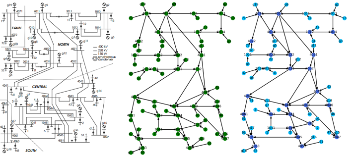

### Some example cases with a transmission Line disconnection:

There are three cases of result.

#### Case One:

The disturbance does not influence the power and voltage. Think if we disconnect a light in Lab, it will make no difference for the whole power system.

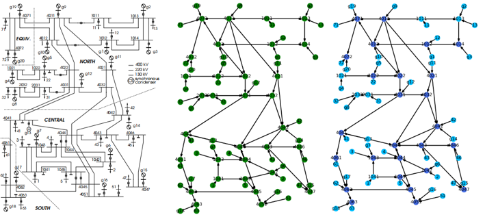

#### Case two:

The disturbance leads to relatively voltage flutuation and sufficient of reactive power. However, it does not cause the blackout.

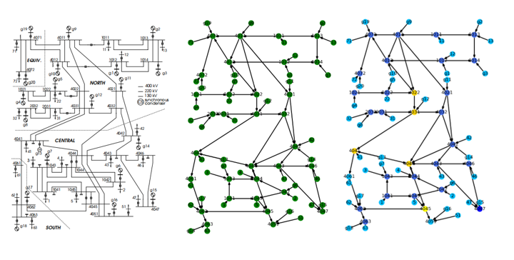

#### Case three:

The disturbance cause a voltage casading and finally it lead to a blackout.

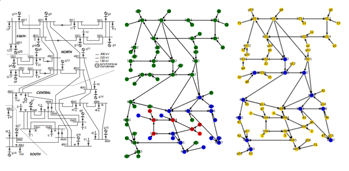